# 210B Lab Report 1

Anagha Uppal

2/19/2018

### PART 1:

#### Background

[output not shown]

```r
## Setting up and choosing libraries and importing data
setwd("~/Desktop/Anagha/UCSB/Classes/GEOG 210B")

if(require('readr')==FALSE)  {
  install.packages('readr',
                   repos="https://cran.rstudio.com/",
                   quiet=TRUE)
  require('readr')
}
library(psych)

if(require('regclass')==FALSE)  {
  install.packages('regclass',
                   repos="https://cran.rstudio.com/",
                   quiet=TRUE)
  require('regclass')
}
library(stargazer)
library(lmtest)
if(require('car')==FALSE)  {
  install.packages('car',
                   repos="https://cran.rstudio.com/",
                   quiet=TRUE)
  require('car')
}
if(require('leaps')==FALSE)  {
  install.packages('leaps',
                   repos="https://cran.rstudio.com/",
                   quiet=TRUE)
  require('leaps')
}
```

```r
## Importing data and initial description
SmallHHfile <- read_csv("SmallHHfile.csv")
```

```r
summary(SmallHHfile)
```

```
##      SAMPN             INCOM           HHSIZ           HHEMP
##  Min.   :1031985   Min.   : 1.00   Min.   :1.000   Min.   :0.000
##  1st Qu.:1661868   1st Qu.: 4.00   1st Qu.:2.000   1st Qu.:1.000
##  Median :1971814   Median : 5.00   Median :2.000   Median :1.000
##  Mean   :2588379   Mean   :13.18   Mean   :2.572   Mean   :1.222
##  3rd Qu.:2829998   3rd Qu.: 7.00   3rd Qu.:3.000   3rd Qu.:2.000
##  Max.   :7212388   Max.   :99.00   Max.   :8.000   Max.   :6.000
##      HHSTU            HHLIC            DOW           HTRIPS
##  Min.   :0.0000   Min.   :0.000   Min.   :1.00   Min.   : 0.00
##  1st Qu.:0.0000   1st Qu.:1.000   1st Qu.:2.00   1st Qu.: 3.00
##  Median :0.0000   Median :2.000   Median :4.00   Median : 6.00
##  Mean   :0.6441   Mean   :1.861   Mean   :4.02   Mean   : 8.29
##  3rd Qu.:1.0000   3rd Qu.:2.000   3rd Qu.:6.00   3rd Qu.:12.00
##  Max.   :8.0000   Max.   :8.000   Max.   :7.00   Max.   :99.00
##       Mon              Tue              Wed              Thu
##  Min.   :0.0000   Min.   :0.0000   Min.   :0.0000   Min.   :0.0000
##  1st Qu.:0.0000   1st Qu.:0.0000   1st Qu.:0.0000   1st Qu.:0.0000
##  Median :0.0000   Median :0.0000   Median :0.0000   Median :0.0000
##  Mean   :0.1364   Mean   :0.1442   Mean   :0.1447   Mean   :0.1473
##  3rd Qu.:0.0000   3rd Qu.:0.0000   3rd Qu.:0.0000   3rd Qu.:0.0000
##  Max.   :1.0000   Max.   :1.0000   Max.   :1.0000   Max.   :1.0000
##       Fri              Sat              Sun           TotDist
##  Min.   :0.0000   Min.   :0.0000   Min.   :0.000   Min.   :   0.000
##  1st Qu.:0.0000   1st Qu.:0.0000   1st Qu.:0.000   1st Qu.:   8.591
##  Median :0.0000   Median :0.0000   Median :0.000   Median :  33.894
##  Mean   :0.1395   Mean   :0.1409   Mean   :0.147   Mean   :  68.093
##  3rd Qu.:0.0000   3rd Qu.:0.0000   3rd Qu.:0.000   3rd Qu.:  82.496
##  Max.   :1.0000   Max.   :1.0000   Max.   :1.000   Max.   :5838.261
##      center           suburb           exurb            rural
##  Min.   :0.0000   Min.   :0.0000   Min.   :0.0000   Min.   :0.0000
##  1st Qu.:0.0000   1st Qu.:0.0000   1st Qu.:0.0000   1st Qu.:0.0000
##  Median :0.0000   Median :0.0000   Median :0.0000   Median :0.0000
##  Mean   :0.2809   Mean   :0.2878   Mean   :0.2289   Mean   :0.2018
##  3rd Qu.:1.0000   3rd Qu.:1.0000   3rd Qu.:0.0000   3rd Qu.:0.0000
##  Max.   :1.0000   Max.   :1.0000   Max.   :1.0000   Max.   :1.0000
##      other      highinc           HHVEH           HHBIC
##  Min.   :0   Min.   :0.0000   Min.   :0.000   Min.   : 0.000
##  1st Qu.:0   1st Qu.:0.0000   1st Qu.:1.000   1st Qu.: 0.000
##  Median :0   Median :0.0000   Median :2.000   Median : 1.000
##  Mean   :0   Mean   :0.4132   Mean   :1.862   Mean   : 1.584
##  3rd Qu.:0   3rd Qu.:1.0000   3rd Qu.:2.000   3rd Qu.: 2.000
##  Max.   :0   Max.   :1.0000   Max.   :8.000   Max.   :99.000
##      VEHNEW           OWN            CarBuy           snglhm
##  Min.   :1.000   Min.   :1.000   Min.   :0.0000   Min.   :0.0000
##  1st Qu.:1.000   1st Qu.:1.000   1st Qu.:0.0000   1st Qu.:1.0000
##  Median :2.000   Median :1.000   Median :0.0000   Median :1.0000
##  Mean   :2.153   Mean   :1.244   Mean   :0.4526   Mean   :0.8177
##  3rd Qu.:2.000   3rd Qu.:1.000   3rd Qu.:1.0000   3rd Qu.:1.0000
##  Max.   :9.000   Max.   :9.000   Max.   :1.0000   Max.   :1.0000
##      ownhm           MilesPr            TrpPrs
##  Min.   :0.0000   Min.   :   0.00   Min.   : 0.000
##  1st Qu.:1.0000   1st Qu.:   4.33   1st Qu.: 1.500
##  Median :1.0000   Median :  14.50   Median : 3.000
##  Mean   :0.7733   Mean   :  27.12   Mean   : 3.280
##  3rd Qu.:1.0000   3rd Qu.:  32.28   3rd Qu.: 4.667
##  Max.   :1.0000   Max.   :1167.65   Max.   :32.000
```

```r
describe(SmallHHfile) #different way to describe the data available
```

```
##         vars     n       mean         sd     median    trimmed       mad
## SAMPN      1 42431 2588378.63 1641345.14 1971814.00 2195483.36 847148.74
## INCOM      2 42431      13.18      26.29       5.00       5.51      2.97
## HHSIZ      3 42431       2.57       1.37       2.00       2.40      1.48
## HHEMP      4 42431       1.22       0.88       1.00       1.18      1.48
## HHSTU      5 42431       0.64       1.02       0.00       0.44      0.00
## HHLIC      6 42431       1.86       0.85       2.00       1.81      0.00
## DOW        7 42431       4.02       1.99       4.00       4.02      2.97
## HTRIPS     8 42431       8.29       7.78       6.00       7.14      5.93
## Mon        9 42431       0.14       0.34       0.00       0.05      0.00
## Tue       10 42431       0.14       0.35       0.00       0.06      0.00
## Wed       11 42431       0.14       0.35       0.00       0.06      0.00
## Thu       12 42431       0.15       0.35       0.00       0.06      0.00
## Fri       13 42431       0.14       0.35       0.00       0.05      0.00
## Sat       14 42431       0.14       0.35       0.00       0.05      0.00
## Sun       15 42431       0.15       0.35       0.00       0.06      0.00
## TotDist   16 42431      68.09     118.52      33.89      45.44     45.13
## center    17 42431       0.28       0.45       0.00       0.23      0.00
## suburb    18 42431       0.29       0.45       0.00       0.23      0.00
## exurb     19 42431       0.23       0.42       0.00       0.16      0.00
## rural     20 42431       0.20       0.40       0.00       0.13      0.00
## other     21 42431       0.00       0.00       0.00       0.00      0.00
## highinc   22 42431       0.41       0.49       0.00       0.39      0.00
## HHVEH     23 42431       1.86       1.00       2.00       1.81      1.48
## HHBIC     24 42431       1.58       3.79       1.00       1.20      1.48
## VEHNEW    25 42431       2.15       2.02       2.00       1.57      1.48
## OWN       26 42431       1.24       0.56       1.00       1.16      0.00
## CarBuy    27 42431       0.45       0.50       0.00       0.44      0.00
## snglhm    28 42431       0.82       0.39       1.00       0.90      0.00
## ownhm     29 42431       0.77       0.42       1.00       0.84      0.00
## MilesPr   30 42431      27.12      43.46      14.50      18.40     18.19
## TrpPrs    31 42431       3.28       2.58       3.00       3.02      2.22
##             min        max      range  skew kurtosis      se
## SAMPN   1031985 7212388.00 6180403.00  2.04     3.09 7968.16
## INCOM         1      99.00      98.00  2.92     6.62    0.13
## HHSIZ         1       8.00       7.00  1.03     0.90    0.01
## HHEMP         0       6.00       6.00  0.47     0.33    0.00
## HHSTU         0       8.00       8.00  1.66     2.52    0.00
## HHLIC         0       8.00       8.00  0.60     1.70    0.00
## DOW           1       7.00       6.00  0.00    -1.24    0.01
```

[output cut: 9 more lines]

```
## center        0       1.00       1.00  0.97    -1.05    0.00
## suburb        0       1.00       1.00  0.94    -1.12    0.00
## exurb         0       1.00       1.00  1.29    -0.34    0.00
## rural         0       1.00       1.00  1.49     0.21    0.00
## other         0       0.00       0.00   NaN      NaN    0.00
## highinc       0       1.00       1.00  0.35    -1.88    0.00
## HHVEH         0       8.00       8.00  0.80     2.26    0.00
## HHBIC         0      99.00      99.00 20.40   513.75    0.02
## VEHNEW        1       9.00       8.00  2.38     4.20    0.01
## OWN           1       9.00       8.00  5.96    67.49    0.00
## CarBuy        0       1.00       1.00  0.19    -1.96    0.00
## snglhm        0       1.00       1.00 -1.65     0.71    0.00
## ownhm         0       1.00       1.00 -1.31    -0.29    0.00
## MilesPr       0    1167.65    1167.65  5.15    47.24    0.21
## TrpPrs        0      32.00      32.00  1.27     3.68    0.01
```

### PART 2:

##### Background

[output not shown]

##### Model Overview

[output not shown]

```r
#creating linear regression model
linearMod <- lm(MilesPr ~ Mon + Tue + Wed + Thu + Fri+ Sat + HHVEH + HHSIZ + suburb + exurb+ rural, data=SmallHHfile)
```

Equation:
$$19.0766418 - 0.6796353*Mon + 0.7147255*Tue + 0.9586046*Wed + 0.6662031*Thu + 3.7856796*Fri + 3.5689737*Sat + 4.8943467*HHVEH - 2.3604597*HHSIZ + 3.1183357*suburb + 6.2514926*exurb + 6.9114198*rural$$

```r
##check_regression(linearMod)
#initial visual check of model
residuals <- resid(linearMod)
summary(residuals)
```

```
##     Min.  1st Qu.   Median     Mean  3rd Qu.     Max.
##  -63.991  -21.268  -11.211    0.000    5.274 1138.791
```

```r
#ks.test(linearMod)
```

I have no idea why my check_regression function doesn’t work and doesn’t automatically switch from the Shapiro-Wilkes test to the Kolmogorov test due to the sample size being greater than 5000. So I have to produce these tests individually. The first of these would be an examination of the residuals-fitted plot and the qq-plot for normality. We see that the mean of residuals is 0, as occurs for a line of best fit.

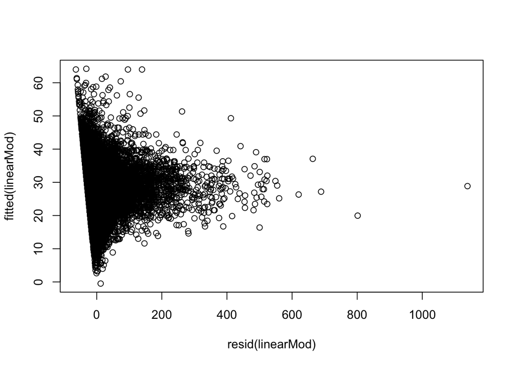

```r
plot(resid(linearMod),fitted(linearMod))
```

It looks like there is a trend in the residual plot, indicating that the regression line might not have been computed correctly. The data is also definitely heteroscedastic.

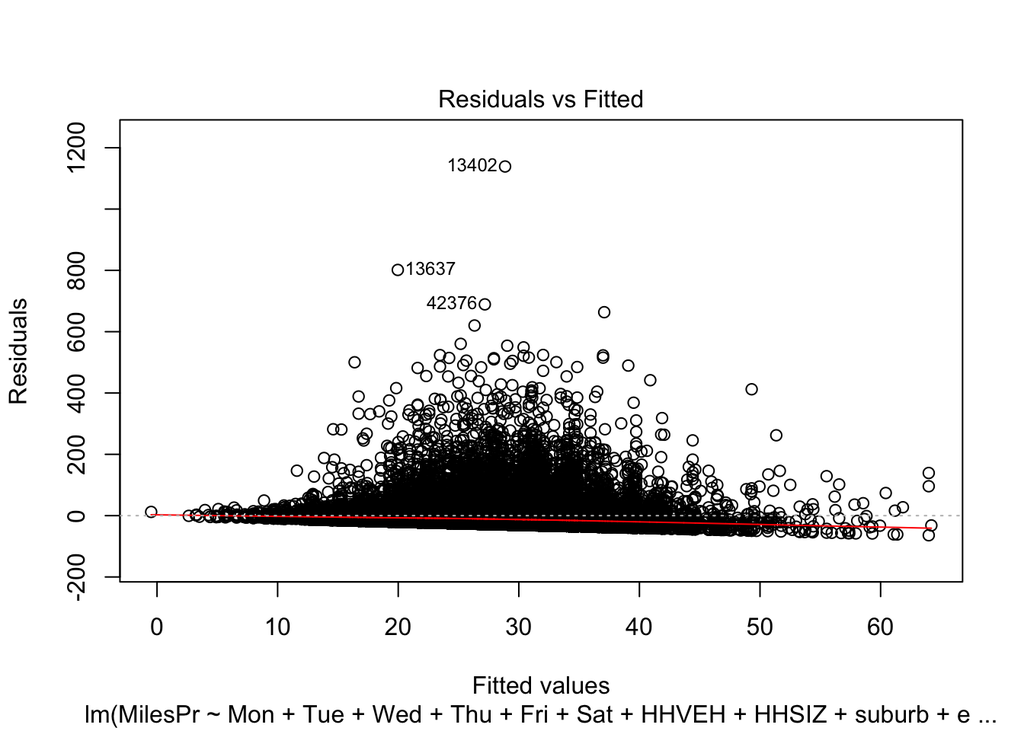

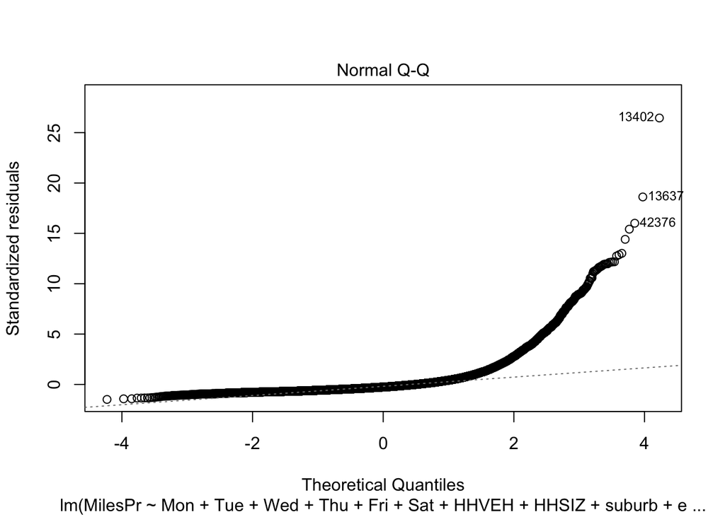

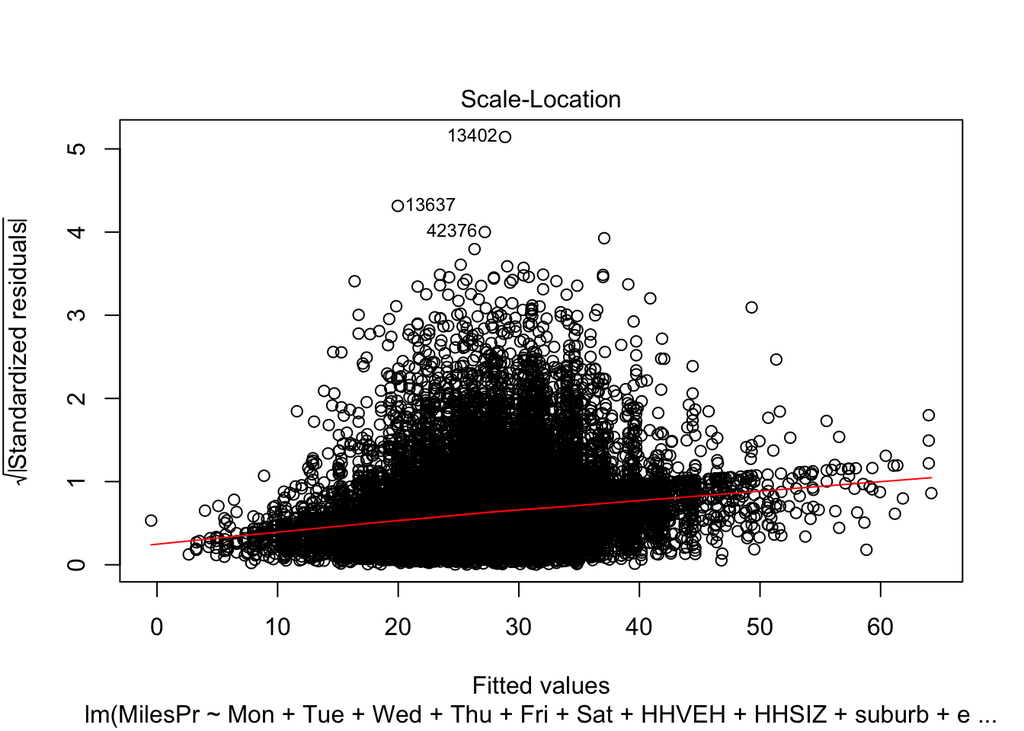

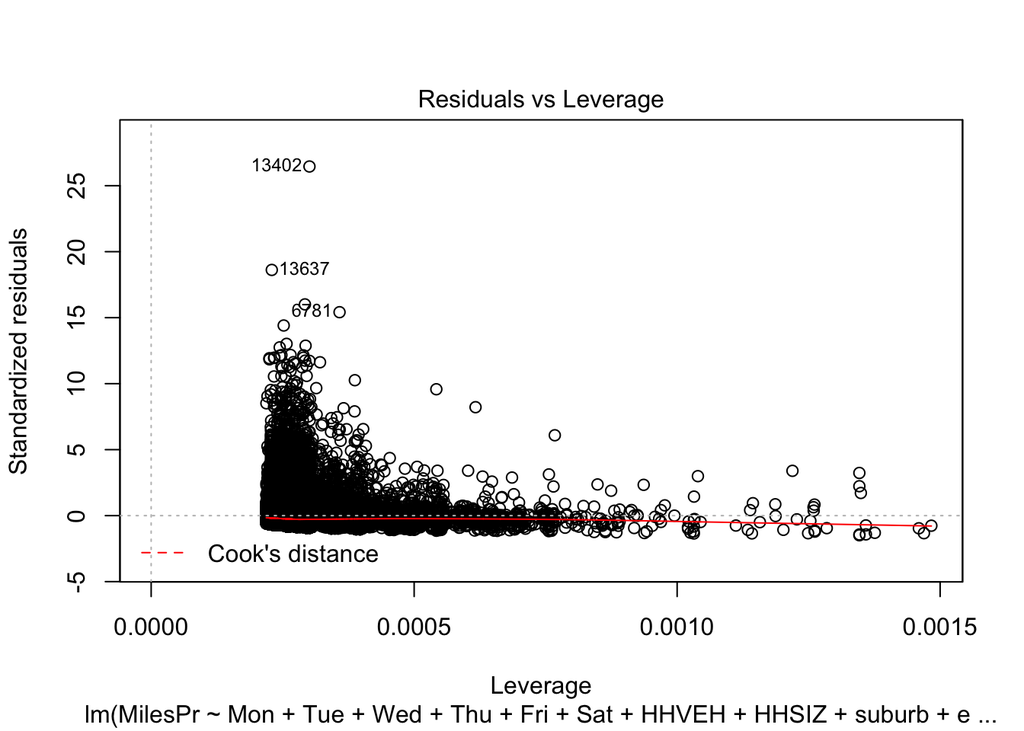

```r
plot(linearMod)
```

We see that the qq-plot is definitely not normal; in fact, it is highly skewed.

Since the predictor variables are mostly categorical and a few dichotomous variables, ANOVA is a better measure than linear regression.

```r
anova(linearMod)
```

```
## Analysis of Variance Table
##
## Response: MilesPr
##              Df   Sum Sq Mean Sq  F value    Pr(>F)
## Mon           1    21132   21132  11.4003  0.000735 ***
## Tue           1     8751    8751   4.7211  0.029801 *
## Wed           1     5020    5020   2.7081  0.099846 .
## Thu           1    19795   19795  10.6788  0.001085 **
## Fri           1    15403   15403   8.3094  0.003946 **
## Sat           1    41561   41561  22.4213 2.196e-06 ***
## HHVEH         1   692384  692384 373.5245 < 2.2e-16 ***
## HHSIZ         1   395581  395581 213.4064 < 2.2e-16 ***
## suburb        1     6637    6637   3.5804  0.058470 .
## exurb         1    70752   70752  38.1688 6.547e-10 ***
## rural         1   232463  232463 125.4082 < 2.2e-16 ***
## Residuals 42419 78630003    1854
## ---
## Signif. codes:  0 '***' 0.001 '**' 0.01 '*' 0.05 '.' 0.1 ' ' 1
```

The difficulty with ANOVA is that it cannot speak to the value of the model as a whole, only compare individual coefficients. For these individual coefficients, Monday and Saturday, along with HHVEH and HHSIZ and the exurb/rural locations are significant. It seems strange that suburb, for instance, does not also show significance alongside the other dummy variables for that category.

```r
summary(linearMod)
```

```
##
## Call:
## lm(formula = MilesPr ~ Mon + Tue + Wed + Thu + Fri + Sat + HHVEH +
##     HHSIZ + suburb + exurb + rural, data = SmallHHfile)
##
## Residuals:
##     Min      1Q  Median      3Q     Max
##  -63.99  -21.27  -11.21    5.27 1138.79
##
## Coefficients:
##             Estimate Std. Error t value Pr(>|t|)
## (Intercept)  19.0766     0.7715  24.728  < 2e-16 ***
## Mon          -0.6796     0.7858  -0.865    0.387
## Tue           0.7147     0.7750   0.922    0.356
## Wed           0.9586     0.7744   1.238    0.216
## Thu           0.6662     0.7709   0.864    0.387
## Fri           3.7857     0.7814   4.845 1.27e-06 ***
## Sat           3.5690     0.7794   4.579 4.69e-06 ***
## HHVEH         4.8943     0.2314  21.148  < 2e-16 ***
## HHSIZ        -2.3605     0.1657 -14.242  < 2e-16 ***
## suburb        3.1183     0.5583   5.585 2.34e-08 ***
## exurb         6.2515     0.5947  10.513  < 2e-16 ***
## rural         6.9114     0.6172  11.199  < 2e-16 ***
## ---
## Signif. codes:  0 '***' 0.001 '**' 0.01 '*' 0.05 '.' 0.1 ' ' 1
##
## Residual standard error: 43.05 on 42419 degrees of freedom
## Multiple R-squared:  0.01884,    Adjusted R-squared:  0.01858
## F-statistic: 74.03 on 11 and 42419 DF,  p-value: < 2.2e-16
```

[output not shown]

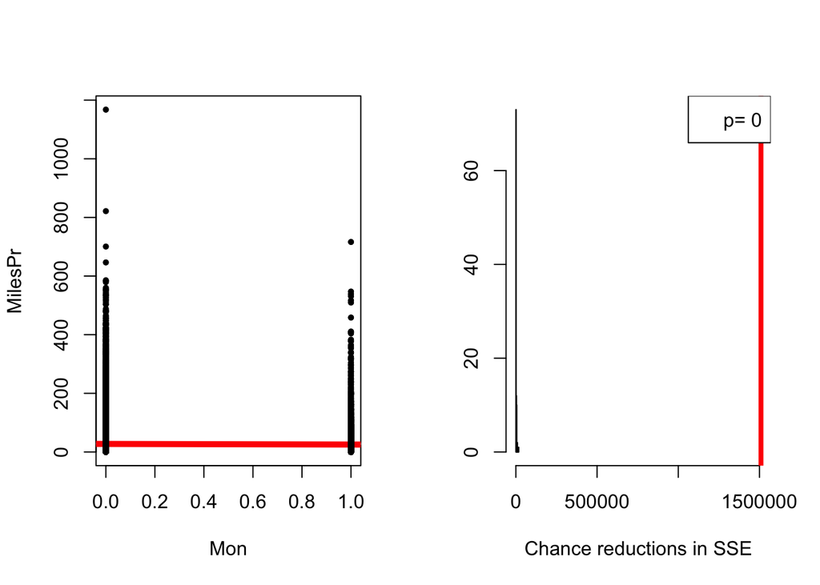

```r
possible_regressions(linearMod)
```

Both the scatterplot-fitted regression line and the reduction in SSE plots indicate that the fitted regression line are unlikely to have occurred by chance. It is very unlikely that no relationship exists between the variables.

```r
confint(linearMod, level = 0.95)
```

```
##                  2.5 %     97.5 %
## (Intercept) 17.5645465 20.5887370
## Mon         -2.2198995  0.8606289
## Tue         -0.8043249  2.2337759
## Wed         -0.5591624  2.4763716
## Thu         -0.8447470  2.1771533
## Fri          2.2541965  5.3171627
## Sat          2.0412746  5.0966728
## HHVEH        4.4407392  5.3479543
## HHSIZ       -2.6853093 -2.0356101
## suburb       2.0240717  4.2125996
## exurb        5.0859431  7.4170420
## rural        5.7017555  8.1210841
```

0 appeared within the confidence interval for Monday, Tuesday, Wednesday, and Thursday. Through this diagnostic, every other variable is significant. Most of these seem to overlap with other summaries and tests.

```r
dwtest(linearMod)
```

```
##
##  Durbin-Watson test
##
## data:  linearMod
## DW = 1.9732, p-value = 0.002827
## alternative hypothesis: true autocorrelation is greater than 0
```

The data is serially autocorrelated, i.e. there is a time-based effect on the model. The p-value for the test is 0.003.

```r
bptest(linearMod)
```

```
##
##  studentized Breusch-Pagan test
##
## data:  linearMod
## BP = 132.78, df = 11, p-value < 2.2e-16
```

```r
coeftest(linearMod,vcov=hccm(linearMod))
```

```
##
## t test of coefficients:
##
##             Estimate Std. Error  t value  Pr(>|t|)
## (Intercept) 19.07664    0.80631  23.6593 < 2.2e-16 ***
## Mon         -0.67964    0.81252  -0.8365    0.4029
## Tue          0.71473    0.77641   0.9205    0.3573
## Wed          0.95860    0.78389   1.2229    0.2214
## Thu          0.66620    0.75662   0.8805    0.3786
## Fri          3.78568    0.86107   4.3965 1.103e-05 ***
## Sat          3.56897    0.89141   4.0038 6.245e-05 ***
## HHVEH        4.89435    0.22038  22.2086 < 2.2e-16 ***
## HHSIZ       -2.36046    0.15069 -15.6642 < 2.2e-16 ***
## suburb       3.11834    0.50840   6.1336 8.666e-10 ***
## exurb        6.25149    0.58097  10.7604 < 2.2e-16 ***
## rural        6.91142    0.63388  10.9033 < 2.2e-16 ***
## ---
## Signif. codes:  0 '***' 0.001 '**' 0.01 '*' 0.05 '.' 0.1 ' ' 1
```

White’s test is most useful when the heteroskedacity is non-linear and the error terms are not normally distributed. In this case, heteroskedacity is present (high BP; low p-value), so we should use a covariance matrix. I don’t really know what to do with the coeftest information.

```r
VIF(linearMod)
```

```
##      Mon      Tue      Wed      Thu      Fri      Sat    HHVEH    HHSIZ
## 1.665244 1.696848 1.698583 1.709006 1.677316 1.683424 1.217594 1.186706
##   suburb    exurb    rural
## 1.462300 1.428897 1.404472
```

```r
#generalization_error()
```

VIF values for the variables aren’t very high, indicating a lack of collinearity between the predictor variables.

```r
#ALL <- regsubsets(MilesPr~.^2,data=SmallHHfile,method="exhaustive",nvmax=15,nbest=4, really.big = T)
#see_models(ALL,aicc=TRUE,report=5)
    extractAIC(linearMod)
```

```
## [1]     12.0 319301.5
```

The AIC looks to be quite high, suggesting that this is a good-quality model. Unfortunately, the functions to compare models to choose the ones with the highest AIC isn’t executing properly, so I can’t establish whether there are better models to be made (without a lot of manual labor).

### PART 3:

##### Background

[output not shown]

##### Model Overview

[output not shown]

To create the models, I will remove the dependendent variable choice not used as an explanatory variable because TrpPrs and HTRIPS would probably covary. I will also remove SAMPN that refers to unique identifier.

```r
linearMod2 <- lm(TrpPrs~.-HTRIPS-SAMPN, data=SmallHHfile)
summary(linearMod2)
```

```
##
## Call:
## lm(formula = TrpPrs ~ . - HTRIPS - SAMPN, data = SmallHHfile)
##
## Residuals:
##      Min       1Q   Median       3Q      Max
## -16.7076  -1.6597  -0.3371   1.2530  27.4181
##
## Coefficients: (3 not defined because of singularities)
##               Estimate Std. Error t value Pr(>|t|)
## (Intercept)  4.9382431  0.5737031   8.608  < 2e-16 ***
## INCOM       -0.0004289  0.0004582  -0.936 0.349188
## HHSIZ       -0.2834729  0.0182005 -15.575  < 2e-16 ***
## HHEMP        0.2598359  0.0168694  15.403  < 2e-16 ***
## HHSTU        0.3935463  0.0199015  19.775  < 2e-16 ***
## HHLIC       -0.1039754  0.0233799  -4.447 8.72e-06 ***
## DOW         -0.3259217  0.0433655  -7.516 5.77e-14 ***
## Mon         -1.4163956  0.2420185  -5.852 4.88e-09 ***
## Tue         -0.6997884  0.1991953  -3.513 0.000443 ***
## Wed         -0.4208987  0.1567994  -2.684 0.007271 **
## Thu         -0.0910912  0.1150957  -0.791 0.428693
## Fri          0.1527969  0.0756836   2.019 0.043505 *
## Sat                 NA         NA      NA       NA
## Sun                 NA         NA      NA       NA
## TotDist     -0.0010713  0.0002164  -4.950 7.43e-07 ***
## center       0.3898390  0.4894948   0.796 0.425798
## suburb       0.0424567  0.4894271   0.087 0.930872
## exurb       -0.1599949  0.4895688  -0.327 0.743815
## rural       -0.5049390  0.4897355  -1.031 0.302526
## other               NA         NA      NA       NA
## highinc      0.3257159  0.0273878  11.893  < 2e-16 ***
## HHVEH       -0.1419540  0.0170361  -8.333  < 2e-16 ***
## HHBIC        0.0194390  0.0031546   6.162 7.25e-10 ***
## VEHNEW       0.0486478  0.0067814   7.174 7.42e-13 ***
## OWN          0.0349101  0.0359799   0.970 0.331919
## CarBuy       0.2806981  0.0285322   9.838  < 2e-16 ***
## snglhm      -0.1829833  0.0364996  -5.013 5.37e-07 ***
## ownhm       -0.0781111  0.0524106  -1.490 0.136135
## MilesPr      0.0176782  0.0005717  30.923  < 2e-16 ***
## ---
## Signif. codes:  0 '***' 0.001 '**' 0.01 '*' 0.05 '.' 0.1 ' ' 1
##
## Residual standard error: 2.394 on 42405 degrees of freedom
## Multiple R-squared:  0.1386, Adjusted R-squared:  0.1381
## F-statistic:   273 on 25 and 42405 DF,  p-value: < 2.2e-16
```

```r
linearMod3 <- lm(HTRIPS~.-TrpPrs-SAMPN, data=SmallHHfile)
summary(linearMod3)
```

```
##
## Call:
## lm(formula = HTRIPS ~ . - TrpPrs - SAMPN, data = SmallHHfile)
##
## Residuals:
##     Min      1Q  Median      3Q     Max
## -86.161  -3.485  -0.723   2.796  78.984
##
## Coefficients: (3 not defined because of singularities)
##               Estimate Std. Error t value Pr(>|t|)
## (Intercept)  2.5587082  1.4611834   1.751 0.079932 .
## INCOM        0.0001785  0.0011670   0.153 0.878446
## HHSIZ        2.0353975  0.0463555  43.908  < 2e-16 ***
## HHEMP        0.5566830  0.0429653  12.957  < 2e-16 ***
## HHSTU        1.3034294  0.0506879  25.715  < 2e-16 ***
## HHLIC       -0.3314254  0.0595469  -5.566 2.63e-08 ***
## DOW         -0.7256789  0.1104490  -6.570 5.08e-11 ***
## Mon         -3.0286021  0.6164050  -4.913 8.99e-07 ***
## Tue         -1.2062904  0.5073372  -2.378 0.017426 *
## Wed         -0.5903318  0.3993575  -1.478 0.139361
## Thu          0.0972743  0.2931412   0.332 0.740016
## Fri          0.6479975  0.1927611   3.362 0.000775 ***
## Sat                 NA         NA      NA       NA
## Sun                 NA         NA      NA       NA
## TotDist      0.0117546  0.0005512  21.326  < 2e-16 ***
## center       2.2403107  1.2467104   1.797 0.072346 .
## suburb       1.5395805  1.2465380   1.235 0.216806
## exurb        1.0451687  1.2468990   0.838 0.401915
## rural        0.3123064  1.2473235   0.250 0.802294
## other               NA         NA      NA       NA
## highinc      0.9503013  0.0697549  13.623  < 2e-16 ***
## HHVEH       -0.3479386  0.0433898  -8.019 1.09e-15 ***
## HHBIC        0.0497930  0.0080346   6.197 5.80e-10 ***
## VEHNEW       0.0926490  0.0172719   5.364 8.18e-08 ***
## OWN          0.2121959  0.0916384   2.316 0.020586 *
## CarBuy       0.6963460  0.0726696   9.582  < 2e-16 ***
## snglhm      -0.1329833  0.0929619  -1.431 0.152577
## ownhm        0.3262760  0.1334863   2.444 0.014519 *
## MilesPr      0.0057650  0.0014560   3.959 7.53e-05 ***
## ---
## Signif. codes:  0 '***' 0.001 '**' 0.01 '*' 0.05 '.' 0.1 ' ' 1
##
## Residual standard error: 6.098 on 42405 degrees of freedom
## Multiple R-squared:  0.3853, Adjusted R-squared:  0.385
## F-statistic:  1063 on 25 and 42405 DF,  p-value: < 2.2e-16
```

```r
stargazer(linearMod,linearMod2,linearMod3, type="text", title="Regression Results")
```

```
##
## Regression Results
## ========================================================================================================
##                                                     Dependent variable:
##                     ------------------------------------------------------------------------------------
##                              MilesPr                     TrpPrs                       HTRIPS
##                                (1)                         (2)                          (3)
## --------------------------------------------------------------------------------------------------------
## INCOM                                                    -0.0004                      0.0002
##                                                         (0.0005)                      (0.001)
##
## Mon                           -0.680                    -1.416***                    -3.029***
##                              (0.786)                     (0.242)                      (0.616)
##
## Tue                           0.715                     -0.700***                    -1.206**
##                              (0.775)                     (0.199)                      (0.507)
##
## Wed                           0.959                     -0.421***                     -0.590
##                              (0.774)                     (0.157)                      (0.399)
##
## Thu                           0.666                      -0.091                        0.097
##                              (0.771)                     (0.115)                      (0.293)
##
## Fri                          3.786***                    0.153**                     0.648***
##                              (0.781)                     (0.076)                      (0.193)
##
## Sat                          3.569***
##                              (0.779)
##
## Sun
##
##
## TotDist                                                 -0.001***                    0.012***
##                                                         (0.0002)                      (0.001)
##
## center                                                    0.390                       2.240*
##                                                          (0.489)                      (1.247)
##
## HHVEH                        4.894***                   -0.142***                    -0.348***
##                              (0.231)                     (0.017)                      (0.043)
```

[output cut: 48 more lines]

```
##
## highinc                                                 0.326***                     0.950***
##                                                          (0.027)                      (0.070)
##
## Constant                    19.077***                   4.938***                      2.559*
##                              (0.771)                     (0.574)                      (1.461)
##
## --------------------------------------------------------------------------------------------------------
## Observations                  42,431                     42,431                       42,431
## R2                            0.019                       0.139                        0.385
## Adjusted R2                   0.019                       0.138                        0.385
## Residual Std. Error    43.054 (df = 42419)         2.394 (df = 42405)           6.098 (df = 42405)
## F Statistic         74.030*** (df = 11; 42419) 273.030*** (df = 25; 42405) 1,063.255*** (df = 25; 42405)
## ========================================================================================================
## Note:                                                                        *p<0.1; **p<0.05; ***p<0.01
```

```r
linearMod3 <- lm(HTRIPS~.-TrpPrs-SAMPN-Sat-Sun-other, data=SmallHHfile)
```

```r
##check_regression(linearMod)
#initial visual check of model
residuals2 <- resid(linearMod3)
summary(residuals2)
```

```
##     Min.  1st Qu.   Median     Mean  3rd Qu.     Max.
## -86.1615  -3.4853  -0.7227   0.0000   2.7965  78.9836
```

```r
#ks.test(linearMod)
```

We see that the mean of residuals is 0, as occurs for a line of best fit.

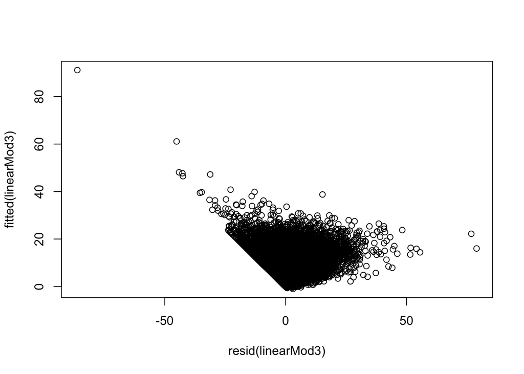

```r
plot(resid(linearMod3),fitted(linearMod3))
```

It looks like there is some sort of trend in the residual plot, a trend that looks very similar to our original model, indicating that the regression line might not have been computed correctly. The data is also still heteroscedastic.

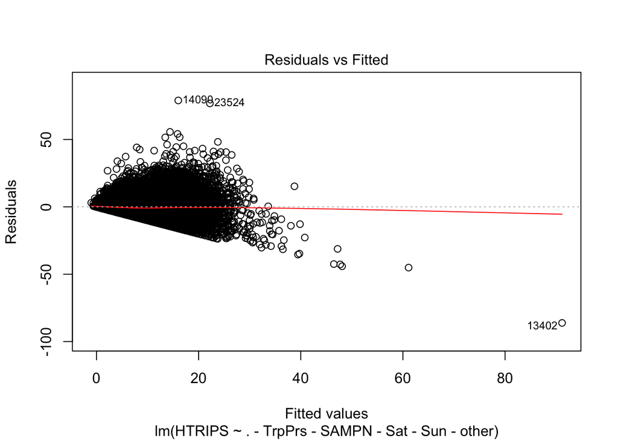

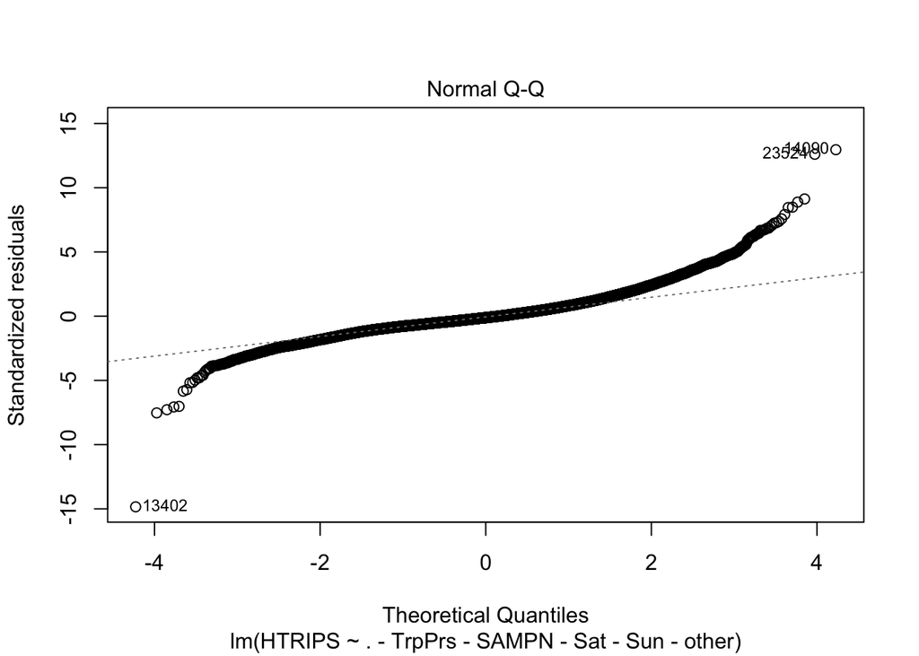

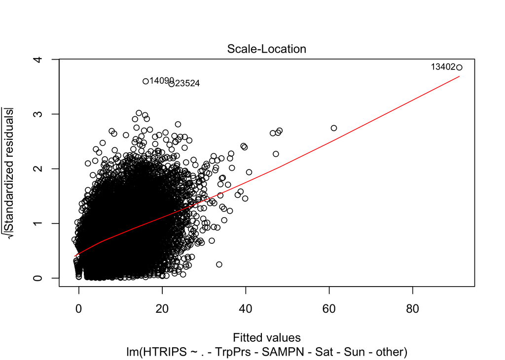

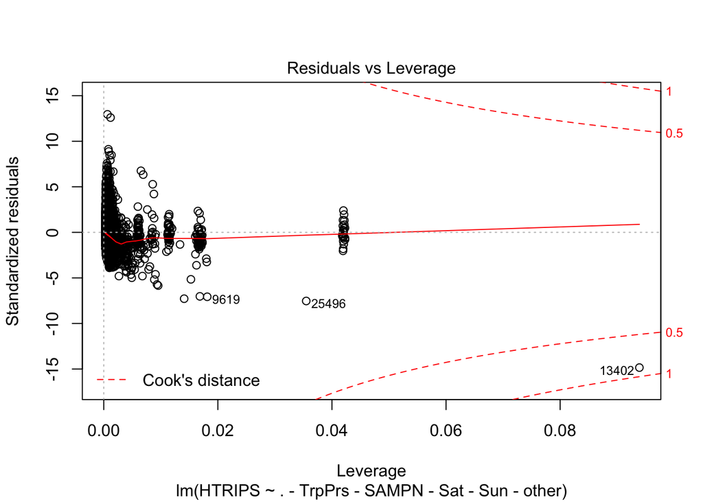

```r
plot(linearMod3)
```

We see that the qq-plot (plot 2) is still not normal and is skewed.

Since the predictor variables are still mostly categorical and a few dichotomous variables, ANOVA is a better measure than linear regression.

```r
anova(linearMod3)
```

```
## Analysis of Variance Table
##
## Response: HTRIPS
##              Df  Sum Sq Mean Sq    F value    Pr(>F)
## INCOM         1    2059    2059    55.3599 1.023e-13 ***
## HHSIZ         1  751267  751267 20200.6703 < 2.2e-16 ***
## HHEMP         1   12100   12100   325.3440 < 2.2e-16 ***
## HHSTU         1   45650   45650  1227.4615 < 2.2e-16 ***
## HHLIC         1    1471    1471    39.5555 3.220e-10 ***
## DOW           1   12685   12685   341.0928 < 2.2e-16 ***
## Mon           1   15757   15757   423.6861 < 2.2e-16 ***
## Tue           1    2624    2624    70.5693 < 2.2e-16 ***
## Wed           1    2692    2692    72.3945 < 2.2e-16 ***
## Thu           1    1278    1278    34.3507 4.636e-09 ***
## Fri           1     286     286     7.7036  0.005514 **
## TotDist       1  100457  100457  2701.1607 < 2.2e-16 ***
## center        1   13612   13612   366.0056 < 2.2e-16 ***
## suburb        1    6517    6517   175.2277 < 2.2e-16 ***
## exurb         1    3514    3514    94.5002 < 2.2e-16 ***
## rural         1       1       1     0.0160  0.899303
## highinc       1    8585    8585   230.8434 < 2.2e-16 ***
## HHVEH         1    2205    2205    59.2911 1.389e-14 ***
## HHBIC         1    1469    1469    39.4945 3.322e-10 ***
## VEHNEW        1       8       8     0.2022  0.652967
## OWN           1      36      36     0.9787  0.322535
## CarBuy        1    3474    3474    93.4134 < 2.2e-16 ***
## snglhm        1      18      18     0.4781  0.489300
## ownhm         1     219     219     5.8934  0.015202 *
## MilesPr       1     583     583    15.6764 7.528e-05 ***
## Residuals 42405 1577049      37
## ---
## Signif. codes:  0 '***' 0.001 '**' 0.01 '*' 0.05 '.' 0.1 ' ' 1
```

```r
summary(linearMod3)
```

```
##
## Call:
## lm(formula = HTRIPS ~ . - TrpPrs - SAMPN - Sat - Sun - other,
##     data = SmallHHfile)
##
## Residuals:
##     Min      1Q  Median      3Q     Max
## -86.161  -3.485  -0.723   2.796  78.984
##
## Coefficients:
##               Estimate Std. Error t value Pr(>|t|)
## (Intercept)  2.5587082  1.4611834   1.751 0.079932 .
## INCOM        0.0001785  0.0011670   0.153 0.878446
## HHSIZ        2.0353975  0.0463555  43.908  < 2e-16 ***
## HHEMP        0.5566830  0.0429653  12.957  < 2e-16 ***
## HHSTU        1.3034294  0.0506879  25.715  < 2e-16 ***
## HHLIC       -0.3314254  0.0595469  -5.566 2.63e-08 ***
## DOW         -0.7256789  0.1104490  -6.570 5.08e-11 ***
## Mon         -3.0286021  0.6164050  -4.913 8.99e-07 ***
## Tue         -1.2062904  0.5073372  -2.378 0.017426 *
## Wed         -0.5903318  0.3993575  -1.478 0.139361
## Thu          0.0972743  0.2931412   0.332 0.740016
## Fri          0.6479975  0.1927611   3.362 0.000775 ***
## TotDist      0.0117546  0.0005512  21.326  < 2e-16 ***
## center       2.2403107  1.2467104   1.797 0.072346 .
## suburb       1.5395805  1.2465380   1.235 0.216806
## exurb        1.0451687  1.2468990   0.838 0.401915
## rural        0.3123064  1.2473235   0.250 0.802294
## highinc      0.9503013  0.0697549  13.623  < 2e-16 ***
## HHVEH       -0.3479386  0.0433898  -8.019 1.09e-15 ***
## HHBIC        0.0497930  0.0080346   6.197 5.80e-10 ***
## VEHNEW       0.0926490  0.0172719   5.364 8.18e-08 ***
## OWN          0.2121959  0.0916384   2.316 0.020586 *
## CarBuy       0.6963460  0.0726696   9.582  < 2e-16 ***
## snglhm      -0.1329833  0.0929619  -1.431 0.152577
## ownhm        0.3262760  0.1334863   2.444 0.014519 *
## MilesPr      0.0057650  0.0014560   3.959 7.53e-05 ***
## ---
## Signif. codes:  0 '***' 0.001 '**' 0.01 '*' 0.05 '.' 0.1 ' ' 1
##
## Residual standard error: 6.098 on 42405 degrees of freedom
## Multiple R-squared:  0.3853, Adjusted R-squared:  0.385
## F-statistic:  1063 on 25 and 42405 DF,  p-value: < 2.2e-16
```

[output not shown]

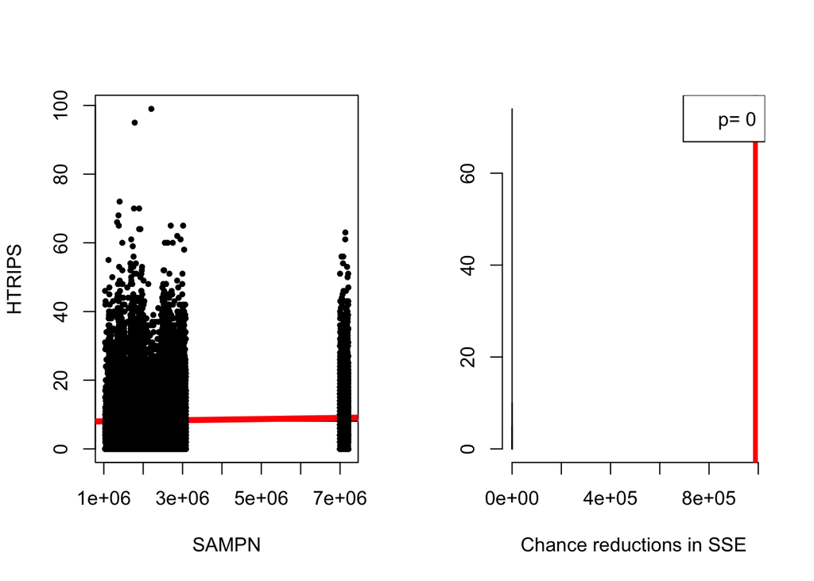

```r
possible_regressions(linearMod3)
```

Both the scatterplot-fitted regression line and the reduction in SSE plots indicate that the fitted regression line are unlikely to have occurred by chance. It is very unlikely that no relationship exists between the variables.

```r
confint(linearMod3, level = 0.95)
```

```
##                    2.5 %       97.5 %
## (Intercept) -0.305240320  5.422656776
## INCOM       -0.002108777  0.002465727
## HHSIZ        1.944539780  2.126255133
## HHEMP        0.472470208  0.640895825
## HHSTU        1.204080134  1.402778739
## HHLIC       -0.448138608 -0.214712265
## DOW         -0.942161219 -0.509196647
## Mon         -4.236768168 -1.820436036
## Tue         -2.200681362 -0.211899426
## Wed         -1.373080506  0.192416918
## Thu         -0.477288209  0.671836821
## Fri          0.270181820  1.025813210
## TotDist      0.010674291  0.012834913
## center      -0.203266510  4.683887955
## suburb      -0.903658763  3.982819727
## exurb       -1.398778309  3.489115610
## rural       -2.132472490  2.757085359
## highinc      0.813580287  1.087022399
## HHVEH       -0.432983546 -0.262893691
## HHBIC        0.034044974  0.065541036
## VEHNEW       0.058795736  0.126502171
## OWN          0.032582788  0.391809071
## CarBuy       0.553912078  0.838779964
## snglhm      -0.315190524  0.049224015
## ownhm        0.064640282  0.587911740
## MilesPr      0.002911088  0.008618813
```

```r
dwtest(linearMod3)
```

```
##
##  Durbin-Watson test
##
## data:  linearMod3
## DW = 1.9735, p-value = 0.003168
## alternative hypothesis: true autocorrelation is greater than 0
```

The data is serially autocorrelated, i.e. there is a time-based effect on the model. The p-value for the test is 0.003. I’d initially noticed the NAs/singularity issue only after computing the Durbin-Watson test and getting an error about element 29 being 0 and matrix inverse being impossible to compute, so this was pretty useful.

```r
bptest(linearMod3)
```

```
##
##  studentized Breusch-Pagan test
##
## data:  linearMod3
## BP = 6842.9, df = 25, p-value < 2.2e-16
```

```r
coeftest(linearMod3,vcov=hccm(linearMod3))
```

```
##
## t test of coefficients:
##
##                Estimate  Std. Error t value  Pr(>|t|)
## (Intercept)  2.55870823  1.55744847  1.6429   0.10041
## INCOM        0.00017847  0.00107234  0.1664   0.86782
## HHSIZ        2.03539746  0.07834586 25.9796 < 2.2e-16 ***
## HHEMP        0.55668302  0.04682225 11.8893 < 2.2e-16 ***
## HHSTU        1.30342944  0.07045223 18.5009 < 2.2e-16 ***
## HHLIC       -0.33142544  0.07974779 -4.1559 3.246e-05 ***
## DOW         -0.72567893  0.11015061 -6.5881 4.508e-11 ***
## Mon         -3.02860210  0.61821965 -4.8989 9.672e-07 ***
## Tue         -1.20629039  0.51014934 -2.3646   0.01805 *
## Wed         -0.59033179  0.40209002 -1.4682   0.14207
## Thu          0.09727431  0.29614676  0.3285   0.74256
## Fri          0.64799752  0.19708581  3.2879   0.00101 **
## TotDist      0.01175460  0.00282146  4.1661 3.104e-05 ***
## center       2.24031072  1.34953132  1.6601   0.09691 .
## suburb       1.53958048  1.34938478  1.1409   0.25390
## exurb        1.04516865  1.34992473  0.7742   0.43879
## rural        0.31230643  1.35022731  0.2313   0.81708
## highinc      0.95030134  0.06987594 13.5998 < 2.2e-16 ***
## HHVEH       -0.34793862  0.04461437 -7.7988 6.392e-15 ***
## HHBIC        0.04979300  0.01079220  4.6138 3.965e-06 ***
## VEHNEW       0.09264895  0.01707116  5.4272 5.755e-08 ***
## OWN          0.21219593  0.11785937  1.8004   0.07180 .
## CarBuy       0.69634602  0.07161828  9.7230 < 2.2e-16 ***
## snglhm      -0.13298325  0.09232507 -1.4404   0.14977
## ownhm        0.32627601  0.15806525  2.0642   0.03901 *
## MilesPr      0.00576495  0.00508680  1.1333   0.25709
## ---
## Signif. codes:  0 '***' 0.001 '**' 0.01 '*' 0.05 '.' 0.1 ' ' 1
```

White’s test (studentized bp) is most useful when the heteroskedacity is non-linear and the error terms are not normally distributed. In this case, heteroskedacity is present (high BP; low p-value), so we should use a covariance matrix.

```r
VIF(linearMod3)
```

```
##      INCOM      HHSIZ      HHEMP      HHSTU      HHLIC        DOW
##   1.073441   4.627019   1.641971   3.066821   2.908661  55.319385
##        Mon        Tue        Wed        Thu        Fri    TotDist
##  51.066996  36.242026  22.517531  12.317359   5.088034   4.868246
##     center     suburb      exurb      rural    highinc      HHVEH
## 358.222069 363.349015 313.128521 285.931618   1.346021   2.133233
##      HHBIC     VEHNEW        OWN     CarBuy     snglhm      ownhm
##   1.055544   1.383915   2.952682   1.492710   1.469734   3.563366
##    MilesPr
##   4.568392
```

```r
#generalization_error()
```

All of the household location dummy variables (center, suburb, exurb, rural) demonstrate a high VIF, indicating a significant degree of collinearity between those explanatory variables. Above, the linear regression summary didn’t show those coefficients as being particularly significant anyway, so we can remove these variables also and re-create the model.

```r
linearMod3 <- lm(HTRIPS~.-TrpPrs-SAMPN-Sat-Sun-other-center-suburb-exurb-rural, data=SmallHHfile)
summary(linearMod3)
```

```
##
## Call:
## lm(formula = HTRIPS ~ . - TrpPrs - SAMPN - Sat - Sun - other -
##     center - suburb - exurb - rural, data = SmallHHfile)
##
## Residuals:
##     Min      1Q  Median      3Q     Max
## -84.064  -3.544  -0.753   2.812  78.345
##
## Coefficients:
##               Estimate Std. Error t value Pr(>|t|)
## (Intercept)  4.2803364  0.7594546   5.636 1.75e-08 ***
## INCOM        0.0020443  0.0011700   1.747 0.080592 .
## HHSIZ        2.0161792  0.0466054  43.261  < 2e-16 ***
## HHEMP        0.6272769  0.0430772  14.562  < 2e-16 ***
## HHSTU        1.3247557  0.0509610  25.996  < 2e-16 ***
## HHLIC       -0.2995299  0.0598597  -5.004 5.64e-07 ***
## DOW         -0.7194918  0.1110505  -6.479 9.34e-11 ***
## Mon         -3.0078340  0.6197489  -4.853 1.22e-06 ***
## Tue         -1.1266826  0.5100592  -2.209 0.027185 *
## Wed         -0.5141469  0.4015009  -1.281 0.200354
## Thu          0.1742448  0.2946941   0.591 0.554340
## Fri          0.6675200  0.1938206   3.444 0.000574 ***
## TotDist      0.0115557  0.0005542  20.851  < 2e-16 ***
## highinc      1.1373101  0.0695517  16.352  < 2e-16 ***
## HHVEH       -0.4526164  0.0433704 -10.436  < 2e-16 ***
## HHBIC        0.0494863  0.0080799   6.125 9.17e-10 ***
## VEHNEW       0.1004937  0.0173649   5.787 7.21e-09 ***
## OWN          0.1890136  0.0921468   2.051 0.040251 *
## CarBuy       0.7299354  0.0730358   9.994  < 2e-16 ***
## snglhm      -0.4348119  0.0921982  -4.716 2.41e-06 ***
## ownhm        0.1277027  0.1338957   0.954 0.340217
## MilesPr      0.0051415  0.0014640   3.512 0.000445 ***
## ---
## Signif. codes:  0 '***' 0.001 '**' 0.01 '*' 0.05 '.' 0.1 ' ' 1
##
## Residual standard error: 6.133 on 42409 degrees of freedom
## Multiple R-squared:  0.3783, Adjusted R-squared:  0.378
## F-statistic:  1229 on 21 and 42409 DF,  p-value: < 2.2e-16
```

A slight decrease in the R-squared! :(

```r
#ALL <- regsubsets(MilesPr~.^2,data=SmallHHfile,method="exhaustive",nvmax=15,nbest=4, really.big = T)
#see_models(ALL,aicc=TRUE,report=5)
    extractAIC(linearMod3)
```

```
## [1]     22.0 153932.2
```

The AIC looks to be quite high, suggesting that this is a good-quality model. Unfortunately, the functions to compare models to choose the ones with the highest AIC isn’t executing properly, so I can’t establish whether there are better models to be made (without a lot of manual labor). (The AIC was quite high even before removing the singular variables)

## ANALYSIS

**2.3 Write a short summary of the model in a similar fashion as our discussion in class highlighting which coefficients are significantly different than zeroand what they tell us.**

```
For the first model, interestingly, the number of miles traveled (per day per person in household) is not correlated with the weekdays Monday-Thursday, but they are correlated with Friday and Saturday. For example, for each day that is Friday, 3.78 more miles will be traveled. One can speculate that people are more likely to travel during the end of the workweek and early weekend, perhaps for chores such as grocery shopping or for short weekend trips. Additionally, number of cars held by the household and number of persons in the household are both significant variables. For each additional car, 4.89 more miles will be traveled by each person in the household. The location of the home is also quite significant, regardless of whether it is suburban, rural or exurban. We did expect that the location would greatly affect the miles traveled. Number of cars and number of persons in household are also pretty expected significant variables. There were a couple more variables that we thought might be significant, but weren't, but overall, this model did not surprise.
```

**3.2 Write a comparison summary between Model 1 and Model 2.**

[output not shown]